```python
#python
%%html
<h1 id="tocheading">Table of Contents</h1>
<div id="toc"></div>
<script src="https://kmahelona.github.io/ipython_notebook_goodies/ipython_notebook_toc.js"></script>
```

Table of Contents

# 概要

前提：L2機能の検証を実施済み AS 64540 と AS 66600間のeBGP接続の冗長接続において、LP値による優先制御機能が働くことを確認する。 優先付け対象経路はAS 64540のネイバーのAS65100から広報されてくる経路を対象とする。

## 項目

MEDの設定 LocalPrefの設定

## MED/LocalPrefの設定

```python
#inventory
[JUNOS:children]
JUNOS1
JUNOS2

[JUNOS1]
10.0.0.107

[JUNOS2]
10.0.0.108

[IOSXR]
10.0.0.109

[localhost]
localhost

[IOSXR:vars]
ansible_user=hogehoge
ansible_ssh_pass=fugafuga
ansible_network_os=iosxr
#Only xRV Option
#ansible_ssh_common_arg="-o HostKeyAlgorithms=ssh-rsa -o KexAlgorithms=diffie-hellman-group1-sha1 -o Ciphers=aes256-cbc,3des-cbc -o MACs=hmac-md5,hmac-sha2-512"

[JUNOS:vars]
ansible_user=hogehoge
ansible_ssh_pass=fugafuga
ansible_network_os=junos
#ansible_ssh_common_args='-o ProxyCommand="ssh -W %h:%p -q bastion01"'
```

```python
#ansible.cfg
[persistent_connection]
command_timeout = 360
connect_timeout = 360
connect_retry_timeout = 360

[defaults]
host_key_checking=False
filter_plugins = /home/notebook/notebooks/nwdiag_filter
```

構成情報の定義方法

```
data[node]：
この配下にNW機器の各インターフェイス情報を格納する
以下、各インターフェイスの情報の項目となる。
    name : NW機器名を定義する
    ifname : NW機器の対象のインターフェイスの名称を定義する
    address : NW機器の対象のインターフェイスのIPv4アドレスを定義する
    vrf : 対象のインターフェイスが所属するvrf名を定義する(任意)
    vlan : 対象のインターフェイスのvlan idを定義する(任意)
    mgmtaddress : 対象のNW機器へのアクセスする管理用アドレス(Ansibleで設定処理するときに使用)
    peeraddress: BGPのピアアドレス(BGPトポ図出力時は必須)
    MED: BGPピアへの広報経路に付与するMED値(任意)
    ASPath: BGPピアへの広報経路に付与するASPathPrepend値(任意)
    LP: BGPピアから受信した経路に対して設定するLocalPreference値(任意)

data[network]:
L3トポ図で作図するネットワークアドレスを指定。
ここで定義されないネットワークは、data[node]のaddressに存在するアドレスから自動生成する
この配下にネットワークアドレスの名称とサブネットを定義した情報を格納する
    name : ネットワークアドレスの名称を定義する(任意)
    address : ネットワークアドレスを定義する※マスク値は二桁で(任意)

data[defaultmask] ：二桁のマスク値
　　　　　　　　　　ここで自動生成するネットワークアドレスのマスク値を定義する。(二桁で)
data[targetrouter]：BGPトポ図作図時は必須。BGP属性を表示する対象のルータを指定する。
```

```python
#vars var
data:
  node:
  - ifname: TenGigE0/0/0/0
    vlan: 2001
    name: ASR01
    address: 172.16.1.2
    mgmtaddress: 10.0.0.109
    AS: 64540
    mtu: 1518
    MED: 110
    ASPath: "64540"
    peeraddress: 172.16.1.1
  - ifname: TenGigE0/0/0/0
    vlan: 2002
    name: ASR01
    address: 172.16.2.2
    mgmtaddress: 10.0.0.109
    AS: 64540
    mtu: 1518
    MED: 100
    ASPath: "64540"
    peeraddress: 172.16.2.1
  - ifname: TenGigE0/0/0/0
    vlan: 2003
    name: ASR01
    address: 172.16.3.2
    mgmtaddress: 10.0.0.109
    AS: 64540
    mtu: 1518
    peeraddress: 172.16.3.10
  - ifname: xe-0/1/0
    vlan: 2003
    name: MX02
    address: 172.16.3.10
    mgmtaddress: 10.0.0.108
    AS: 65100
    peeraddress: 172.16.3.2
  - ifname: xe-0/1/0
    vlan: 2004
    name: MX02
    address: 172.16.4.10
    mgmtaddress: 10.0.0.108
    AS: 65100
  - ifname: xe-0/0/0:0
    vlan: 2001
    name: MX01
    address: 172.16.1.1
    mgmtaddress: 10.0.0.107
    AS: 66600
    mtu: 1500
    LP: 290
    peeraddress: 172.16.1.2
  - ifname: xe-0/0/0:0
    vlan: 2002
    name: MX01
    address: 172.16.2.1
    mgmtaddress: 10.0.0.107
    AS: 66600
    mtu: 1500
    LP: 300
    peeraddress: 172.16.2.2
  network:
  - name: test
    address: 172.16.1.0/24
  - name: test2
    address: 172.16.2.0/24
  - name: test3
    address: 172.16.3.0/24
  - name: test4
    address: 172.16.4.0/24
  defaultmask: 24
  mtu: 8192
  targetrouter: MX01
```

# 構成図作成の事前処理

## inet-henge用のjinja2テンプレート読み込み

```python
#template demo.j2
{
  "nodes": [
{% for router in Routerlist %}
    {
      "meta": {
{% if data.targetrouter == router %}
        "target": "[ TARGET ]"
{% endif %}
      },
     "name": "AS{{ ASlist[loop.index0] }}-{{ router }}",  "icon": "./images/router.png"
{% if loop.last %}
    }
{% else %}
    },
{% endif %}
{% endfor %}
  ],
  "links": [
{% for router in data.node | selectattr("peeraddress", "defined") | list%}
{% set peerAS =  data.node | selectattr('address', 'match', router.peeraddress ) | map(attribute='AS' ) | list %}
{% set peerrouter =  data.node | selectattr('address', 'match', router.peeraddress ) | map(attribute='name' ) | list %}
{% set MED =  data.node | selectattr('address', 'match', router.peeraddress ) | map(attribute='MED' ) | list %}
{% set ASPath =  data.node | selectattr('address', 'match', router.peeraddress ) | map(attribute='ASPath' ) | list %}
{% if not loop.first %}
    },
{% endif %}
    {
      "source": "AS{{ router.AS }}-{{ router.name }}",
{% if data.targetrouter == router.name %}
      "target": "AS{{ peerAS[0] }}-{{ peerrouter[0] }}",
      "meta": {
        "address": {
          "source": "--------{{ router.address }}--------",
          "target": "--------{{ router.peeraddress }}--------"
        },
          "MED/LP/ASPath": "MED:{{ MED[0] | default('default') }}/LP:{{ router.LP | default('default') }}/ASPrepend:{{ ASPath[0] | default(default) }}"
        }
{% else %}
      "target": "AS{{ peerAS[0] }}-{{ peerrouter[0] }}"
{% endif %}

{% endfor %}
    }
  ]
}
```

```python
#play
name: test job
hosts: localhost
connection: local
gather_facts: false
vars_files:
    - var
vars:
  Routerlist: "{{ data.node | json_query('[*].name') | unique }}"
  ASlist: "{{ data.node | json_query('[*].AS') | unique }}"
```

## Jinja2テンプレートからInet-Henge向けJsonファイル生成

```python
#task
name: copy inventory
template:
  src: demo.j2
  dest: /home/notebook/notebooks/inet-henge/example/index.json
```

```
TASK [copy inventory] **********************************************************
ok: [localhost] => {
    "checksum": "6f2973ba31629fb96bdacfc039d51f870e44118d",
    "dest": "/home/notebook/notebooks/inet-henge/example/index.json",
    "diff": {
        "after": {
            "path": "/home/notebook/notebooks/inet-henge/example/index.json"
        },
        "before": {
            "path": "/home/notebook/notebooks/inet-henge/example/index.json"
        }
    },
    "gid": 1000,
    "group": "notebook",
    "mode": "0644",
    "owner": "notebook",
    "path": "/home/notebook/notebooks/inet-henge/example/index.json",
    "size": 1266,
    "state": "file",
    "uid": 1000
}
```

## Inet-hengeの設定ファイル変更

```python
#task
name: index.html configuration
lineinfile: >-
  dest='/home/notebook/notebooks/inet-henge/example/index.html'
  state=present
  backrefs=yes
  regexp='{{ item.regexp }}'
  line='{{ item.line }}'
with_items:
- regexp: "^(.*)diagram.init(.*)$"
  line: "   diagram.init('target', 'address', 'MED/LP/ASPath');"
```

[output not shown]

[output cut: 78 more lines]

```
                    "seuser": null,
                    "src": null,
                    "state": "present",
                    "unsafe_writes": null,
                    "validate": null
                }
            },
            "item": {
                "line": "   diagram.init('target', 'address', 'MED/LP/ASPath');",
                "regexp": "^(.*)diagram.init(.*)$"
            },
            "msg": ""
        }
    ]
}
```

## nwdiag(L3トポ図)の作図情報生成

```python
#task
name: nwdiag
debug:
  msg: "{{ data | nwdiag_filter }}"
register: nwdiag
```

```
TASK [nwdiag] ******************************************************************
ok: [localhost] => {
    "msg": "{\n  network test {\n      address = \"172.16.1.0/24\"\n\n\n      \"ASR01\" [address = \"TenGigE0/0/0/0.2001\\n172.16.1.2\"];\n      \"MX01\" [address = \"xe-0/0/0:0.2001\\n172.16.1.1\"];\n  }\n  network test2 {\n      address = \"172.16.2.0/24\"\n\n\n      \"ASR01\" [address = \"TenGigE…
}
```

# 構成図

## L3トポ図

[output not shown]

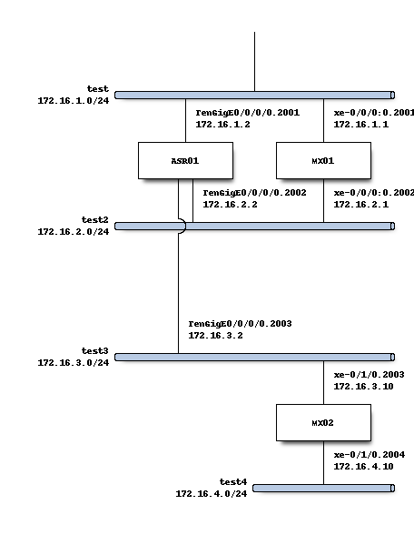

```python
#python
import sys

sys.path.append('/home/notebook/notebooks/a8e8269d4331b6b93e7ef90744fe0b3b/')

%load_ext diagmagic
get_ipython().run_cell_magic('nwdiag', '', nwdiag['msg'])
```

## BGPトポ図

```python
#python
import subprocess
from subprocess import Popen
import time

cmd = "python -m SimpleHTTPServer"
proc = Popen( cmd.split(), stdout=subprocess.PIPE)

time.sleep(5)
from IPython.display import HTML
#http://URL(Jupyter実行しているIPアドレスを指定する)
HTML(r'<iframe width="1024" height="560" src="https://notebook.as2518.net/inet-henge/example/" frameborder="0" allowfullscreen></iframe>')
```

[interactive chart not shown]

# IOSXR(AS64540)への設定

```python
#play
name: test job
hosts: IOSXR
connection: network_cli
gather_facts: false
vars_files:
    - var
```

## すべて許可するroute-policy作成

```python
#task
name: |
   - route-policy ALLPASS
   - pass
   - exit
iosxr_config:
  commands:
   - pass
   - exit
  parents: route-policy ALLPASS
  match: none
register: result
```

```
TASK [- route-policy ALLPASS
- pass
- exit
] ***********************************
changed: [10.0.0.109] => {
    "commands": [
        "route-policy ALLPASS",
        "pass",
        "exit"
    ]
}
```

## MEDをつけるroute-policyを作成

```python
name: |
   - route-policy med{{ item.MED }}-out
   - set med {{ item.MED }}
   - end-policy
iosxr_config:
  lines:
   - set med {{ item.MED }}
   - end-policy
  parents: route-policy med{{ item.MED }}-out
  force: yes
register: result
when: ansible_host == item.mgmtaddress
with_items:
  - "{{ data.node | selectattr('MED', 'defined') | list }}"
```

[output not shown]

[output cut: 230 more lines]

```
                "address": "172.16.2.2",
                "ifname": "TenGigE0/0/0/0",
                "mgmtaddress": "10.0.0.109",
                "mtu": 1518,
                "name": "ASR01",
                "peeraddress": "172.16.2.1",
                "vlan": 2002
            }
        }
    ],
    "warnings": [
        "The force argument is deprecated, please use match=none instead.  This argument will be removed in the future",
        "The force argument is deprecated, please use match=none instead.  This argument will be removed in the future"
    ]
}
```

## Vlan I/Fを作成する

```python
#task
name: |
   - interface {{ item.ifname }}
   - mtu {{ data.mtu }}
   - dot1q native vlan 1
   - no shutdown
iosxr_config:
  lines:
   - dot1q vlan {{ item.vlan }}
   - no shutdown
   - ipv4 address {{ item.address }}/{{ data.defaultmask }}
   - mtu {{ item.mtu }}
  parents: interface {{ item.ifname }}.{{ item.vlan }}
when: ansible_host == item.mgmtaddress
with_items:
  - "{{ data.node }}"
register: result
```

[output not shown]

[output cut: 642 more lines]

```
                "AS": 66600,
                "LP": 300,
                "address": "172.16.2.1",
                "ifname": "xe-0/0/0:0",
                "mgmtaddress": "10.0.0.107",
                "mtu": 1500,
                "name": "MX01",
                "peeraddress": "172.16.2.2",
                "vlan": 2002
            },
            "skip_reason": "Conditional result was False",
            "skipped": true
        }
    ]
}
```

## BGPの設定追加①(MEDをつけるピア向け)

```python
#task
name: |
   - bgp router-id 2.2.2.2
   - address-family ipv4 unicast
   - neighbor {{ item.peeraddress }} remote-as {{ data.node | selectattr('address', 'match', item.peeraddress ) | map(attribute='AS' ) | max }}
   - neighbor {{ item.peeraddress }} address-family ipv4 unicast
   - neighbor {{ item.peeraddress }} address-family ipv4 unicast route-policy ALLPASS in
   - neighbor {{ item.peeraddress }} address-family ipv4 unicast route-policy med{{ item.MED }}-out out
iosxr_config:
  lines:
   - bgp router-id 2.2.2.2
   - address-family ipv4 unicast
   - neighbor {{ item.peeraddress }} remote-as {{ data.node | selectattr('address', 'match', item.peeraddress ) | map(attribute='AS' ) | max }}
   - neighbor {{ item.peeraddress }} address-family ipv4 unicast
   - neighbor {{ item.peeraddress }} address-family ipv4 unicast route-policy ALLPASS in
   - neighbor {{ item.peeraddress }} address-family ipv4 unicast route-policy med{{ item.MED }}-out out
  parents: router bgp {{ item.AS }}
register: result
when: ansible_host == item.mgmtaddress
with_items:
  - "{{ data.node | selectattr('MED', 'defined') | list}}"
```

[output not shown]

[output cut: 227 more lines]

```
            "item": {
                "AS": 64540,
                "ASPath": "64540",
                "MED": 100,
                "address": "172.16.2.2",
                "ifname": "TenGigE0/0/0/0",
                "mgmtaddress": "10.0.0.109",
                "mtu": 1518,
                "name": "ASR01",
                "peeraddress": "172.16.2.1",
                "vlan": 2002
            }
        }
    ]
}
```

## BGPの設定追加②(その他ピア向け)

```python
#task
name: |
   - bgp router-id 2.2.2.2
   - address-family ipv4 unicast
   - neighbor {{ item.peeraddress }} remote-as {{ data.node | selectattr('address', 'match', router.peeraddress ) | map(attribute='MED' ) | max }}
   - neighbor {{ item.peeraddress }} address-family ipv4 unicast
   - neighbor {{ item.peeraddress }} address-family ipv4 unicast route-policy ALLPASS in
   - neighbor {{ item.peeraddress }} address-family ipv4 unicast route-policy med{{ item.MED }}-out out
iosxr_config:
  lines:
   - bgp router-id 2.2.2.2
   - address-family ipv4 unicast
   - neighbor {{ item.peeraddress }} remote-as {{ data.node | selectattr('address', 'match', item.peeraddress ) | map(attribute='AS' ) | max }}
   - neighbor {{ item.peeraddress }} address-family ipv4 unicast
   - neighbor {{ item.peeraddress }} address-family ipv4 unicast route-policy ALLPASS in
   - neighbor {{ item.peeraddress }} address-family ipv4 unicast route-policy ALLPASS out
  parents: router bgp {{ item.AS }}
register: result
when: ansible_host == item.mgmtaddress
with_items:
  - "{{ data.node | selectattr('MED', 'undefined') | list}}"
```

[output not shown]

[output cut: 356 more lines]

```
                "AS": 66600,
                "LP": 300,
                "address": "172.16.2.1",
                "ifname": "xe-0/0/0:0",
                "mgmtaddress": "10.0.0.107",
                "mtu": 1500,
                "name": "MX01",
                "peeraddress": "172.16.2.2",
                "vlan": 2002
            },
            "skip_reason": "Conditional result was False",
            "skipped": true
        }
    ]
}
```

## BGPのセッションクリア

```python
name: clear bgp ipv4 unicast {{ item.peeraddress }} soft out
iosxr_command:
  commands:
   - clear bgp ipv4 unicast {{ item.peeraddress }} soft out
register: result
when: ansible_host == item.mgmtaddress
with_items:
  - "{{ data.node | selectattr('peeraddress', 'defined') | list}}"
```

[output not shown]

[output cut: 523 more lines]

```
                "AS": 66600,
                "LP": 300,
                "address": "172.16.2.1",
                "ifname": "xe-0/0/0:0",
                "mgmtaddress": "10.0.0.107",
                "mtu": 1500,
                "name": "MX01",
                "peeraddress": "172.16.2.2",
                "vlan": 2002
            },
            "skip_reason": "Conditional result was False",
            "skipped": true
        }
    ]
}
```

# JUNOS2(AS65100)設定

```python
#play
name: test job
hosts: JUNOS2
gather_facts: false
vars_files:
    - var
```

[output not shown]

## Router-ID設定

```python
#task
name: |
   - set routing-options router-id 3.3.3.3
   - set routing-options autonomous-system {{ data.node | selectattr('mgmtaddress', 'match', ansible_host ) | map(attribute='AS' ) | max }}
connection: netconf
junos_config:
  lines:
   - set routing-options router-id 3.3.3.3
   - set routing-options autonomous-system {{ data.node | selectattr('mgmtaddress', 'match', ansible_host ) | map(attribute='AS' ) | max }}
```

```
TASK [- set routing-options router-id 3.3.3.3
- set routing-options autonomous-system {{ data.node | selectattr('mgmtaddress', 'match', ansible_host ) | map(attribute='AS' ) | max }}
]
ok: [10.0.0.108] => {}
```

## Vlan I/F作成

```python
#task
name: create vlan interfaces
connection: netconf
junos_config:
  lines:
   - set interfaces {{ item.ifname }} flexible-vlan-tagging
   - set interfaces {{ item.ifname }} unit {{ item.vlan }} vlan-id {{ item.vlan }}
   - set interfaces {{ item.ifname }} unit {{ item.vlan }} family inet address {{ item.address }}/{{ data.defaultmask }}
   - set interfaces {{ item.ifname }} unit {{ item.vlan }} family inet mtu {{ item.mtu | default("1500") }}
when: ansible_host == item.mgmtaddress
with_items:
  - "{{ data.node }}"
register: result
```

[output not shown]

[output cut: 546 more lines]

```
                "AS": 66600,
                "LP": 300,
                "address": "172.16.2.1",
                "ifname": "xe-0/0/0:0",
                "mgmtaddress": "10.0.0.107",
                "mtu": 1500,
                "name": "MX01",
                "peeraddress": "172.16.2.2",
                "vlan": 2002
            },
            "skip_reason": "Conditional result was False",
            "skipped": true
        }
    ]
}
```

## Redistribute Directのポリシー作成

```python
#task
name: |
   - set policy-options policy-statement redist-direct  term 1 from protocol direct
   - set policy-options policy-statement redist-direct  term 1 then accept
connection: netconf
junos_config:
  lines:
   - set policy-options policy-statement redist-direct term 1 from protocol direct
   - set policy-options policy-statement redist-direct  term 1 then accept
```

```
TASK [- set policy-options policy-statement redist-direct  term 1 from protocol direct
- set policy-options policy-statement redist-direct  term 1 then accept
]
ok: [10.0.0.108] => {}
```

```python
#task
name: |
   - set protocols bgp group {{ item.peeraddress }} type external
   - set protocols bgp group {{ item.peeraddress }} hold-time 90
   - set protocols bgp group {{ item.peeraddress }} family inet unicast
   - set protocols bgp group {{ item.peeraddress }} export redist-direct
   - set protocols bgp group {{ item.peeraddress }} neighbor {{ item.peeraddress }} peer-as {{ data.node  | selectattr('address', 'match', item.peeraddress ) | map(attribute='AS' ) | max }}
connection: netconf
junos_config:
  lines:
   - set protocols bgp group {{ item.peeraddress }} type external
   - set protocols bgp group {{ item.peeraddress }} hold-time 90
   - set protocols bgp group {{ item.peeraddress }} family inet unicast
   - set protocols bgp group {{ item.peeraddress }} export redist-direct
   - set protocols bgp group {{ item.peeraddress }} neighbor {{ item.peeraddress }} peer-as {{ data.node  | selectattr('address', 'match', item.peeraddress ) | map(attribute='AS' ) | max }}
when: ansible_host == item.mgmtaddress
with_items:
  - "{{ data.node | selectattr('peeraddress', 'defined') | list }}"
register: result
```

[output not shown]

[output cut: 442 more lines]

```
                "AS": 66600,
                "LP": 300,
                "address": "172.16.2.1",
                "ifname": "xe-0/0/0:0",
                "mgmtaddress": "10.0.0.107",
                "mtu": 1500,
                "name": "MX01",
                "peeraddress": "172.16.2.2",
                "vlan": 2002
            },
            "skip_reason": "Conditional result was False",
            "skipped": true
        }
    ]
}
```

# JUNOS1(AS66600)への設定

```python
#play
name: test job
hosts: JUNOS1
connection: network_cli
gather_facts: false
vars_files:
    - var
```

[output not shown]

## 事前状態確認(広報対象の経路がすでに聞こえていないことを確認する)

```python
#task
name: show route {{  data.network[3]["address"]  }}
junos_command:
  commands:
   - show route {{  data.network[3]["address"]  }}
register: result
```

```
TASK [show route 172.16.4.0/24] ************************************************
```

```python
#task
name: show task result
debug: var=result["stdout_lines"].0
```

```
TASK [show task result] ********************************************************
ok: [10.0.0.107] => {
    "result[\"stdout_lines\"].0": [
        ""
    ]
}
```

## Vlan I/Fの作成

```python
#task
name: create vlan interfaces
connection: network_cli
junos_command:
  commands:
   - configure
   - set interfaces {{ item.ifname }} flexible-vlan-tagging
   - set interfaces {{ item.ifname }} unit {{ item.vlan }} vlan-id {{ item.vlan }}
   - set interfaces {{ item.ifname }} unit {{ item.vlan }} family inet address {{ item.address }}/{{ data.defaultmask }}
   - set interfaces {{ item.ifname }} unit {{ item.vlan }} family inet mtu {{ item.mtu }}
   - commit
   - exit
when: ansible_host == item.mgmtaddress
with_items:
  - "{{ data.node }}"
register: result
```

[output not shown]

[output cut: 668 more lines]

```
                    "commit complete",
                    "",
                    "[edit]"
                ],
                [
                    "Exiting configuration mode"
                ]
            ]
        }
    ],
    "warnings": [
        "arguments wait_for, match, rpcs are not supported when using transport=cli",
        "arguments wait_for, match, rpcs are not supported when using transport=cli"
    ]
}
```

## RouterID/ASの設定

```python
#task
name: |
   - set routing-options router-id 1.1.1.1
   - set routing-options autonomous-system {{ data.node | selectattr('mgmtaddress', 'match', ansible_host ) | map(attribute='AS' ) | max }}
connection: network_cli
junos_command:
  commands:
   - configure
   - set routing-options router-id 1.1.1.1
   - set routing-options autonomous-system {{ data.node | selectattr('mgmtaddress', 'match', ansible_host ) | map(attribute='AS' ) | max }}
   - commit
   - exit
register: result
```

```
TASK [- set routing-options router-id 1.1.1.1
- set routing-options autonomous-system {{ data.node | selectattr('mgmtaddress', 'match', ansible_host ) | map(attribute='AS' ) | max }}
]
```

## LocalPrefの設定

```python
#task
name: |
   - set policy-options policy-statement LP-{{ item.LP }} term 1 then local-preference {{ item.LP }}
   - set policy-options policy-statement LP-{{ item.LP }} term 1 then accept
connection: network_cli
junos_command:
  commands:
   - configure
   - set policy-options policy-statement LP-{{ item.LP }} term 1 then local-preference {{ item.LP }}
   - set policy-options policy-statement LP-{{ item.LP }} term 1 then accept
   - commit
   - exit
when: ansible_host == item.mgmtaddress
with_items:
  - "{{ data.node | selectattr('LP', 'defined') | list }}"
register: result
```

[output not shown]

[output cut: 289 more lines]

```
                    "commit complete",
                    "",
                    "[edit]"
                ],
                [
                    "Exiting configuration mode"
                ]
            ]
        }
    ],
    "warnings": [
        "arguments wait_for, match, rpcs are not supported when using transport=cli",
        "arguments wait_for, match, rpcs are not supported when using transport=cli"
    ]
}
```

## BGP設定の投入

```python
#task
name: |
   - set protocols bgp group {{ item.peeraddress }} type external
   - set protocols bgp group {{ item.peeraddress }} hold-time 90
   - set protocols bgp group {{ item.peeraddress }} family inet unicast
   - set protocols bgp group {{ item.peeraddress }} neighbor {{ item.peeraddress }} peer-as {{ data.node  | selectattr('address', 'match', item.peeraddress ) | map(attribute='AS' ) | max }}
   - set protocols bgp group {{ item.peeraddress }} neighbor {{ item.peeraddress }} import LP-{{ item.LP }}

connection: network_cli
junos_command:
  commands:
   - configure
   - set protocols bgp group {{ item.peeraddress }} type external
   - set protocols bgp group {{ item.peeraddress }} hold-time 90
   - set protocols bgp group {{ item.peeraddress }} family inet unicast
   - set protocols bgp group {{ item.peeraddress }} neighbor {{ item.peeraddress }} peer-as {{ data.node  | selectattr('address', 'match', item.peeraddress ) | map(attribute='AS' ) | max }}
   - set protocols bgp group {{ item.peeraddress }} neighbor {{ item.peeraddress }} import LP-{{ item.LP }}
   - commit
   - exit
when: ansible_host == item.mgmtaddress
with_items:
  - "{{ data.node | selectattr('LP', 'defined') | list }}"
register: result
```

[output not shown]

[output cut: 340 more lines]

```
                    "commit complete",
                    "",
                    "[edit]"
                ],
                [
                    "Exiting configuration mode"
                ]
            ]
        }
    ],
    "warnings": [
        "arguments wait_for, match, rpcs are not supported when using transport=cli",
        "arguments wait_for, match, rpcs are not supported when using transport=cli"
    ]
}
```

## 30秒ほど寝かせる

```python
name: pause 30 sec
pause:
  seconds: 30
```

[output not shown]

# 設定投入後の正常性確認

## Junosルータから受信している経路の一つを選択し、想定どおり(metrix 100)の経路を選定しているかを確認

```python
#task
name: show route {{  data.network[3]["address"]  }}
junos_command:
  commands:
   - show route {{ data.network[3]["address"] }}
register: result
```

```
TASK [show route 172.16.4.0/24] ************************************************
```

```python
#task
name: show task result
debug: var=result["stdout_lines"].0
```

```
TASK [show task result] ********************************************************
ok: [10.0.0.107] => {
    "result[\"stdout_lines\"].0": [
        "inet.0: 42 destinations, 55 routes (42 active, 0 holddown, 0 hidden)",
        "+ = Active Route, - = Last Active, * = Both",
        "",
        "172.16.4.0/24      *[BGP/170] 00:00:22, MED 100, localpref 300",
        "                      AS path: 64540 65100 I, validation-state: unverified",
        "                    >  to 172.16.2.2 via xe-0/0/0:0.2002",
        "                    [BGP/170] 00:00:22, MED 110, localpref 290",
        "                      AS path: 64540 65100 I, validation-state: unverified",
        "                    >  to 172.16.1.2 via xe-0/0/0:0.2001"
    ]
}
```

# 結果(OKかNGか等)

## 想定通りのMED100/LocalPref300の経路が選択されているのでOK

## デモ向け設定削除

```python
#task
name: |
   - delete protocols bgp
   - delete interface xe-0/0/0:0

connection: network_cli
junos_command:
  commands:
   - configure
   - delete protocols bgp
   - delete interface xe-0/0/0:0
   - commit
   - exit
when: ansible_host == item.mgmtaddress
with_items:
  - "{{ data.node | selectattr('LP', 'defined') | list }}"
register: result
```

[output not shown]

[output cut: 303 more lines]

```
                    "commit complete",
                    "",
                    "[edit]"
                ],
                [
                    "Exiting configuration mode"
                ]
            ]
        }
    ],
    "warnings": [
        "arguments wait_for, match, rpcs are not supported when using transport=cli",
        "arguments wait_for, match, rpcs are not supported when using transport=cli"
    ]
}
```

```python
#python
%%html
<style>
div.input {
    display:none;
}
</style>
```